# Analysis of Social Media Usage Among Students

**Author:** Tina Mariyam Jacab

**Enrollment No:** 2505101270264

**Date:** 23 September 2026

## 1. Introduction

This Tiny Project analyzes a small fictional dataset of 30 students to study daily social media usage, study time, sleep hours and academic performance.

## 2. Data Importing

The data are imported from `social_media_usage_students.csv` using `read.csv()`.

[output not shown]

## 3. Data Preprocessing and Cleaning

Two missing numeric observations were included intentionally. They were detected with `is.na()` and replaced using the median.

**Missing values after cleaning:** 0 in all columns.

## 4. Statistical Analysis

| Measure | Result |
| --- | --- |
| Mean social media usage | 3.10 hours/day |
| Median social media usage | 3.00 hours/day |
| Standard deviation | 1.03 hours |
| Mean study time | 2.55 hours/day |
| Mean academic performance | 77.00 |

## 5. Platform Analysis

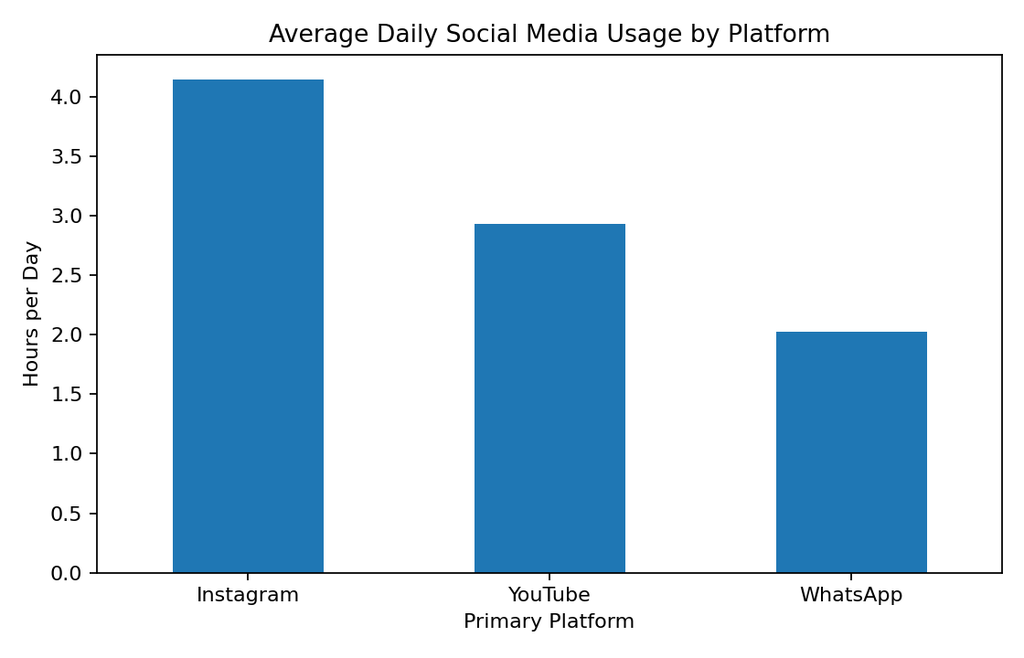

The chart compares average daily social media usage by primary platform.

## 6. Distribution of Social Media Usage

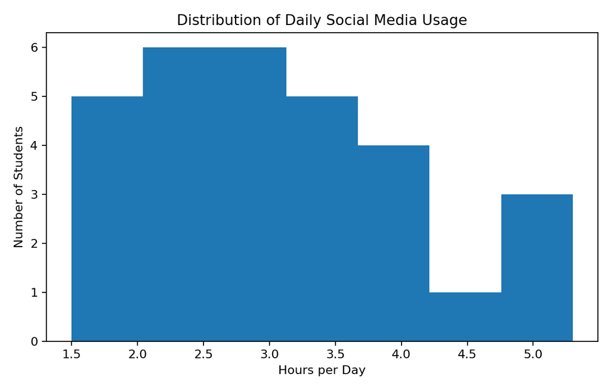

The histogram shows the distribution of daily usage among students.

## 7. Main Purpose of Social Media Use

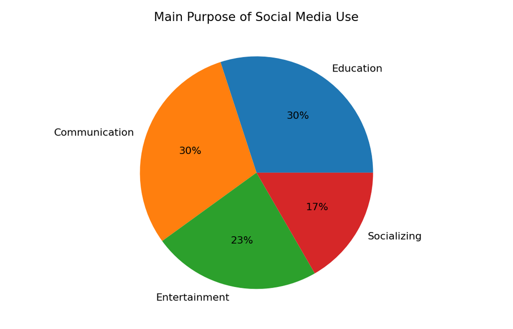

The pie chart summarizes the main purpose reported by students.

## 8. Social Media Usage vs Academic Performance

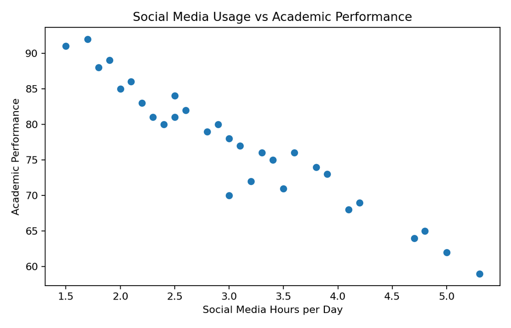

The correlation between social media hours and academic performance is **-0.962**. Correlation indicates association, not causation.

## 9. Findings

1. Students use social media for communication, education, entertainment and socializing.
2. Average daily usage is 3.10 hours.
3. Usage differs among students.
4. The platform and purpose charts show differences in usage patterns.
5. The correlation analysis describes the relationship between social media usage and academic performance for this sample.

## 10. Conclusion

R can be used to import, clean, summarize and visualize student social media data. This project demonstrates a complete small data-analysis workflow using R.

**Note:** The dataset is fictional and intended only for academic demonstration.